# Estimating Employment in the Alcohol Manufacturing Industry in the Philippines

AJ Montesa

2024-12-01

## Introduction

The objective of this analysis is to estimate the total number of people employed in the alcohol manufacturing industry in the Philippines. This estimation is essential for assessing the economic implications of potential policy changes, such as increases in alcohol taxation. Given the lack of direct employment data, this analysis leverages multiple data sources, including the **Labor Force Survey (LFS)** and the **Annual Survey of Philippine Businesses and Industry (ASPBI)**, to produce a transparent and robust estimate.

The methodology combines aggregate employment figures from the LFS with detailed industry-level proportions from the ASPBI, adjusted to account for inconsistencies and under-reporting. This document outlines the steps taken, assumptions made, and calculations performed to ensure the results are reproducible and defensible.

This exercise is motivated by the alcohol industry’s frequent use of employment as a key argument against raising alcohol taxes. Despite this, the industry often lacks transparency in providing reliable data on employment levels and offers little evidence regarding the sensitivity of employment to changes in market consumption. Policymakers and stakeholders are left without a clear picture of how many people are employed in the sector and the extent to which tax increases may affect these jobs. By systematically estimating employment in the alcohol manufacturing industry using publicly available data, this analysis seeks to provide a more transparent, data-driven basis for evaluating these claims. Such evidence is crucial for framing policy discussions in a manner that balances economic considerations with public health objectives.

## Data Sources

### Labor Force Survey (LFS)

The LFS provides individual-level employment data, including industry **divisions** based on the **Philippine Standard Industrial Classification (PSIC)** such as **“Manufacture of Beverages” (C11)** and **“Manufacture of Tobacco Products” (C12)**. For this analysis, the LFS serves as the primary source for total employment figures within these divisions, ensuring comprehensive coverage of both formal and informal employment.

### Annual Survey of Philippine Businesses and Industry (ASPBI)

The ASPBI offers firm-level data with more granular industry Classes, such as **“Distilling, Rectifying, and Blending of Spirits” (C1101)** and **“Manufacture of Malt Liquors and Malt” (C1103)**. This data is used to calculate the proportion of employment attributable to specific sub-industries within the broader divisions identified in the LFS.

By combining these two datasets, we aim to address the limitations of each and produce a detailed estimate of employment in the alcohol manufacturing industry.

### Philippine Standard Industrial Classification (PSIC)

The analysis relies on the Philippine Standard Industrial Classification (PSIC) for consistent categorization of industries across data sources. The PSIC is a detailed framework that classifies industries based on the type of productive activities undertaken by establishments. It ensures uniformity and comparability in identifying and analyzing industries in the Philippines.

In this study, data from the Labor Force Survey (LFS) and the Annual Survey of Philippine Businesses and Industry (ASPBI) use PSIC codes to classify industries. The LFS tags industry employment up to the 2-digit Division Code, providing aggregate-level insights into sectors such as “Manufacture of Beverages” (C11). Meanwhile, the ASPBI provides more granular classification up to the 4-digit Class Code, allowing us to examine specific sub-industries, such as “Distilling, Rectifying, and Blending of Spirits” (C1101) or “Manufacture of Malt Liquors and Malt” (C1103).

The 2-digit Division Code C11, “Manufacture of Beverages,” encompasses a broad range of activities related to the production of beverages. This includes both non-alcoholic beverages (e.g., soft drinks and mineral water) and alcoholic beverages, such as beer, wine, and distilled spirits. However, it excludes the production of fruit and vegetable juices, milk-based drinks, and products like coffee and tea.

At the 4-digit Class Code level, the PSIC provides further specificity. For example:

- C1101: “Distilling, Rectifying, and Blending of Spirits” includes activities like manufacturing distilled alcoholic beverages (e.g., whisky, gin, brandy) and blending or rectifying distilled spirits.
- C1102: “Manufacture of Wines” focuses on wine production.
- C1103: “Manufacture of Malt Liquors and Malt” covers the production of beer, ale, and similar products, as well as non-alcoholic beer and malt.
- Other class codes, such as C1104 to C1106, cover the manufacture of soft drinks, mineral water, sports drinks, and related beverages.

The distinction between Division and Class Codes is central to the methodology: while the LFS provides employment totals at the broader Division Code level (C11), the ASPBI’s Class Code breakdown allows us to estimate the proportional contribution of specific sub-industries to the overall employment in beverage manufacturing. This hierarchical structure of the PSIC enables a detailed yet consistent approach to integrating data from these two sources.

Wine manufacturing was excluded from this analysis due to its relatively small contribution to the Philippine beverage manufacturing industry. In the local context, wine production represents a niche segment, with much of it consisting of traditional or artisanal wines such as tapuy (rice wine) and lambanog (coconut wine). These products are predominantly produced by small-scale or informal enterprises, which often fall outside the formal tax system and are not captured comprehensively in official data sources like the ASPBI. Consequently, the employment impact of wine manufacturing is minimal compared to other sub-industries such as distilling spirits or brewing beer. Including this segment would add limited value to the analysis while introducing potential inaccuracies due to the challenges of quantifying employment in largely informal and non-taxpaying operations.

## Methodology

### Data Cleaning

We first prepared the LFS and ASPBI datasets to ensure consistency in definitions and units across sources. Missing or inconsistent entries were addressed systematically to avoid biases in the analysis.

```r
# Load ASPBI Data ---------------------------------------------------------

## Class
filenames_class <- list.files("Data_Burden/ASPBI", pattern = "Class", full.names = TRUE)

ASPBI_Class <- tibble()

for (f in filenames_class) {
  ASPBI_year <- str_extract(f, "\\d{4}")

  ASPBI_Class <- bind_rows(
    ASPBI_Class,
    read_xlsx(f) %>% mutate(year = ASPBI_year)
  )
}


## Division
filenames_division <- list.files("Data_Burden/ASPBI", pattern = "Division", full.names = TRUE)

ASPBI_Division <- tibble()

for (f in filenames_division) {
  ASPBI_year <- str_extract(f, "\\d{4}")

  ASPBI_Division <- bind_rows(
    ASPBI_Division,
    read_xlsx(f) %>% mutate(year = ASPBI_year)
  )
}
```

```r
# Load LFS Data -----------------------------------------------------------

lfs_microdata_07to22 <- read_rds("Data_Burden/lfs_microdata_07to22.rds")

lfs_year_bevtob <- lfs_microdata_07to22 %>%
  filter(as.double(year) >= 2012, primary_kindbusiness %in% c("11", "12")) %>%
  group_by(year, quarter, primary_kindbusiness) %>%
  summarize(primary_basicpayperday = weighted.mean(x = primary_basicpayperday, w = wgt, na.rm = TRUE),
            wgt = sum(wgt, na.rm = TRUE)) %>%
  group_by(year, primary_kindbusiness) %>%
  summarize(primary_basicpayperday = weighted.mean(x = primary_basicpayperday, w = wgt, na.rm = TRUE),
            wgt = mean(wgt, na.rm = TRUE)) %>%
  mutate(year = as.Date(str_c(year, "-01-01")),
         psic_division = case_when(primary_kindbusiness == "11" ~ "C11 Manufacture of Beverages",
                                   primary_kindbusiness == "12" ~ "C12 Manufacture of Tobacco Products")) %>%
  ungroup()

lfs_year_manufacturing <- lfs_microdata_07to22 %>%
  filter(as.double(year) >= 2012, primary_kindbusiness_ind %in% c("2009-C Manufacturing")) %>%
  group_by(year, quarter, primary_kindbusiness_ind) %>%
  summarize(primary_basicpayperday = weighted.mean(x = primary_basicpayperday, w = wgt, na.rm = TRUE),
            wgt = sum(wgt, na.rm = TRUE)) %>%
  group_by(year, primary_kindbusiness_ind) %>%
  summarize(primary_basicpayperday = weighted.mean(x = primary_basicpayperday, w = wgt, na.rm = TRUE),
            wgt = mean(wgt, na.rm = TRUE)) %>%
  ungroup() %>%
  transmute(year = as.Date(str_c(year, "-01-01")),
            PSIC_Section = "C Manufacturing",
            Section_WagePerWorker = primary_basicpayperday,
            Section_Workers = wgt)
```

### Calculating Sub-Division Proportions

Using ASPBI data, we calculated the share of employment attributable to specific industry Classes (e.g., C1101) relative to their parent Divisions (e.g., C11). This provides a granular breakdown of employment within the alcohol manufacturing industry.

### Smoothing Year-to-Year Fluctuations

To mitigate large year-to-year swings in ASPBI data, we applied a weighted 5-year rolling mean of the share of employment in the industry Class to its parent Division, including 2 lagged and 2 lead values. This smooths out anomalies and produces more stable Class share estimates.

```r
# Calculate ASPBI Shares --------------------------------------------------

roll_wgts_5yr <- c(0.1, 0.2, 0.4, 0.2, 0.1)
roll_wgts_3yr <- c(0.25, 0.5, 0.25)

ASPBI_ClassShares <- left_join(
  ASPBI_Class %>%
    transmute(year, Ind_Class,
              Ind_Division = str_sub(Ind_Class, 1, 3),
              Class_Workers = Workers_Male + Workers_Female,
              Class_WagePerWorker = Expense_Wages/Class_Workers),
  ASPBI_Division %>%
    transmute(year, Ind_Division,
              Division_Workers = Workers_Male + Workers_Female,
              Division_WagePerWorker = Expense_Wages/Division_Workers)
) %>%
  group_by(Ind_Class) %>%
  arrange(Ind_Class, year) %>%
  mutate(year = as.Date(str_c(year, "-01-01")),
         primary_kindbusiness = str_sub(Ind_Division, 2, 3),
         Class_Share = Class_Workers/Division_Workers,
         Class_WageRatio = Class_WagePerWorker/Division_WagePerWorker) %>%
  mutate(Class_Share_3Yr = roll_mean(Class_Share, n = 3, weights = roll_wgts_3yr, fill = NA, na.rm = TRUE, align = "center"),
         Class_Share_5Yr = roll_mean(Class_Share, n = 5, weights = roll_wgts_5yr, fill = NA, na.rm = TRUE, align = "center")) %>%
  mutate(Class_Share_3Yr = if_else(is.na(Class_Share_3Yr), Class_Share, Class_Share_3Yr),
         Class_Share_5Yr = if_else(is.na(Class_Share_5Yr), Class_Share_3Yr, Class_Share_5Yr))
```

### Extrapolating Employment Figures

We multiplied the smoothed sub-division shares (ASPBI) by the total employment figures for the respective divisions (LFS) to estimate sub-industry employment. This step integrates the aggregate and granular data to produce a comprehensive estimate.

```r
# Merge Data Sets and Extrapolate -----------------------------------------

C12_table <- tibble(
  year = seq.Date(from = as.Date("2012-01-01"), by = "1 year", length.out = 11),
  Ind_Class = "C12",
  Ind_Division = "C12",
  Class_Workers = lfs_year_bevtob %>% filter(psic_division == "C12 Manufacture of Tobacco Products") %>% .$wgt,
  Class_WagePerWorker = lfs_year_bevtob %>% filter(psic_division == "C12 Manufacture of Tobacco Products") %>% .$primary_basicpayperday,
  Division_Workers = Class_Workers,
  Division_WagePerWorker = Class_WagePerWorker,
  primary_kindbusiness = "12",
  Class_Share = 1, Class_Share_3Yr = 1, Class_Share_5Yr = 1,
  Class_WageRatio = 1,
  primary_basicpayperday = Class_WagePerWorker,
  wgt = Class_Workers
)


extrapolated <- left_join(ASPBI_ClassShares, lfs_year_bevtob) %>%
  bind_rows(C12_table) %>%
  transmute(year, Ind_Class, Ind_Division = psic_division,
            ExtrapolatedWorkers = Class_Share*wgt,
            ExtrapolatedWorkers_3Yr = Class_Share_3Yr*wgt,
            ExtrapolatedWorkers_5Yr = Class_Share_5Yr*wgt,
            primary_basicpayperday,
            PSIC_Class = case_when(Ind_Class == "C1101" ~ "C1101 Distilling, rectifying, and blending of spirits",
                                   Ind_Class == "C1103" ~ "C1103 Manufacture of malt liquors and malt",
                                   Ind_Class == "C1201" ~ "C1201 Manufacture of cigarettes",
                                   Ind_Class == "C12" ~ "C12 Manufacture of tobacco products")) %>%
  left_join(lfs_year_manufacturing)
```

### Limitations of the Methodology

While the above method systematically integrates complementary data sources and employs sound statistical techniques to address their respective strengths and limitations, several limitations must be acknowledged:

- The ASPBI likely under-reports employment in micro and small enterprises, which could result in conservative estimates.
- The smoothing technique applied to ASPBI data may mask genuine short-term variations.
- Assumptions regarding the proportional contribution of sub-industries may not fully capture industry-specific dynamics.

Future research could address these limitations by incorporating additional data sources, such as field surveys or industry reports, to validate and refine the estimates.

## Results

#### Estimated Number of Workers Employed in the Alcohol Manufacturing Sector

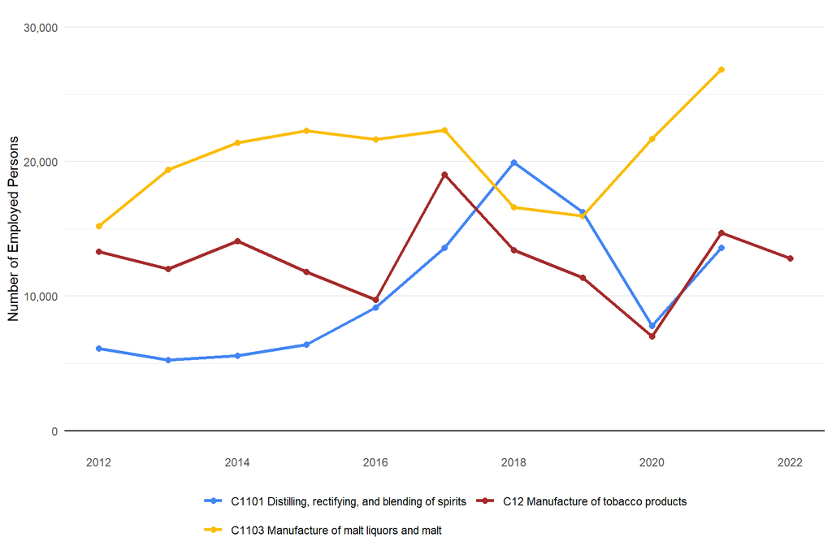

|  | C1101 Distilling, rectifying, and blending of spirits | C1103 Manufacture of malt liquors and malt | C12 Manufacture of tobacco products |
| --- | --- | --- | --- |
| 2012 | 6,117.4 | 15,193.9 | 13,323.2 |
| 2013 | 5,267.6 | 19,384.6 | 12,016.7 |
| 2014 | 5,561.4 | 21,386.3 | 14,101.9 |
| 2015 | 6,408.7 | 22,302.8 | 11,821.9 |
| 2016 | 9,140.0 | 21,657.4 | 9,719.4 |
| 2017 | 13,593.9 | 22,342.4 | 19,029.8 |
| 2018 | 19,947.7 | 16,596.9 | 13,426.0 |
| 2019 | 16,260.6 | 15,944.3 | 11,358.4 |
| 2020 | 7,804.9 | 21,698.0 | 6,991.8 |
| 2021 | 13,601.4 | 26,857.0 | 14,689.5 |
| 2022 | NA | NA | 12,796.8 |

#### Estimated Share of Alcohol Manufacturing Sector to Manufacturing

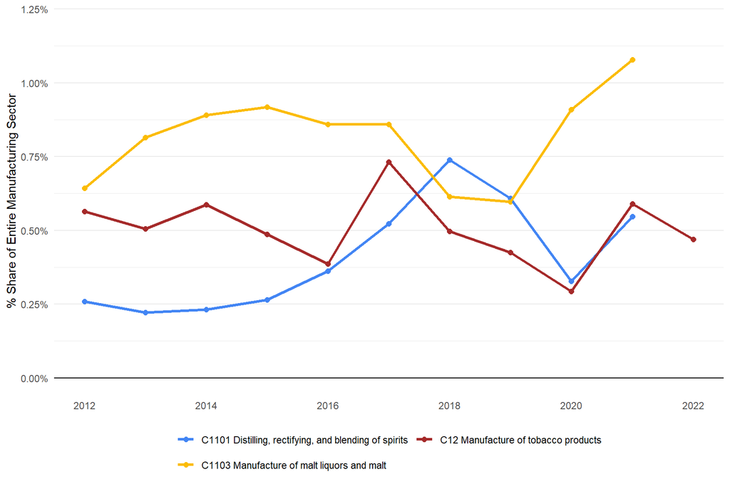

|  | C1101 Distilling, rectifying, and blending of spirits | C1103 Manufacture of malt liquors and malt | C12 Manufacture of tobacco products |
| --- | --- | --- | --- |
| 2012 | 0.26% | 0.64% | 0.56% |
| 2013 | 0.22% | 0.81% | 0.51% |
| 2014 | 0.23% | 0.89% | 0.59% |
| 2015 | 0.26% | 0.92% | 0.49% |
| 2016 | 0.36% | 0.86% | 0.39% |
| 2017 | 0.52% | 0.86% | 0.73% |
| 2018 | 0.74% | 0.61% | 0.50% |
| 2019 | 0.61% | 0.60% | 0.42% |
| 2020 | 0.33% | 0.91% | 0.29% |
| 2021 | 0.55% | 1.08% | 0.59% |
| 2022 | NA | NA | 0.47% |

#### Estimated Total Wages Paid in the Alcohol Manufacturing Sector

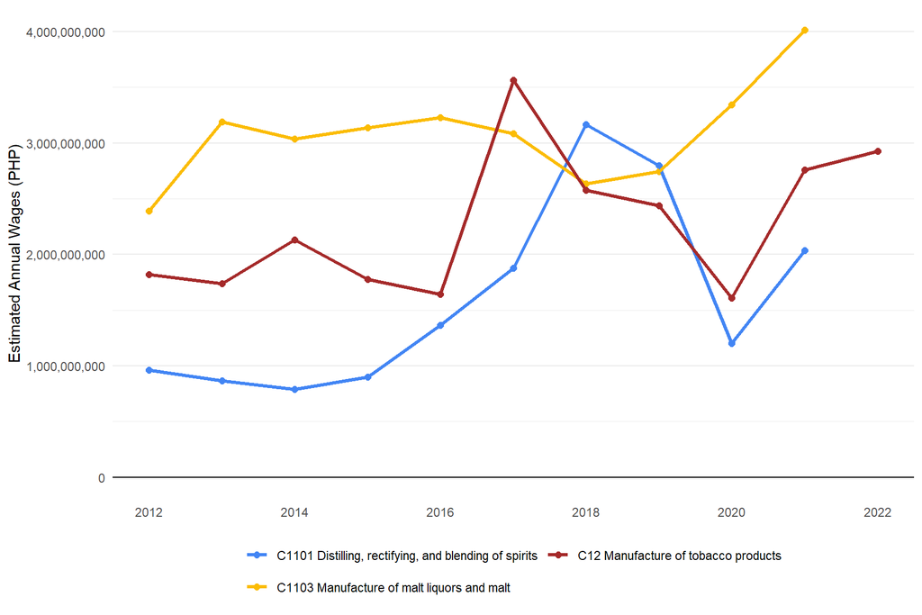

|  | C1101 Distilling, rectifying, and blending of spirits | C1103 Manufacture of malt liquors and malt | C12 Manufacture of tobacco products |
| --- | --- | --- | --- |
| 2012 | 962,768,860 | 2,391,267,373 | 1,819,758,098 |
| 2013 | 866,831,703 | 3,189,896,389 | 1,736,091,924 |
| 2014 | 789,774,218 | 3,037,084,390 | 2,130,510,108 |
| 2015 | 901,637,508 | 3,137,774,257 | 1,775,000,187 |
| 2016 | 1,363,441,084 | 3,230,697,139 | 1,642,215,332 |
| 2017 | 1,878,034,158 | 3,086,668,289 | 3,562,370,863 |
| 2018 | 3,166,851,362 | 2,634,876,120 | 2,576,351,827 |
| 2019 | 2,798,423,326 | 2,743,983,602 | 2,437,062,322 |
| 2020 | 1,201,953,895 | 3,341,500,503 | 1,609,985,682 |
| 2021 | 2,033,214,779 | 4,014,723,522 | 2,758,312,453 |
| 2022 | NA | NA | 2,928,962,074 |

The analysis reveals that **the alcohol manufacturing industry employs less than 2% of the total workforce in the Manufacturing sector**. This finding underscores the relatively small footprint of alcohol manufacturing in the broader industrial landscape. Even in scenarios where tax increases lead to reduced alcohol consumption and potential job losses in this sector, it is reasonable to expect many displaced workers to transition into the production of non-alcoholic beverages, where consumer spending is likely to shift. This natural reallocation of jobs mitigates the industry’s claims of widespread economic disruption, highlighting the adaptability of the manufacturing labor market.